# bike_share_data_analysis

Kexin(Daisy) Zhang

2024-01-03

##Loading packages

```r
install.packages('tidyverse')
install.packages('janitor')
install.packages('ggmap')
install.packages('lubridate')
install.packages('dplyr')
```

##Loading libraries

[output not shown]

## Import 12 months Cyclistic data

```r
nov23 <- read.csv("/Users/bluesww/Desktop/Cyclistic data/csv/202311-divvy-tripdata.csv")
oct23 <- read.csv("/Users/bluesww/Desktop/Cyclistic data/csv/202310-divvy-tripdata.csv")
sep23 <- read.csv("/Users/bluesww/Desktop/Cyclistic data/csv/202309-divvy-tripdata.csv")
aug23 <- read.csv("/Users/bluesww/Desktop/Cyclistic data/csv/202308-divvy-tripdata.csv")
jul23 <- read.csv("/Users/bluesww/Desktop/Cyclistic data/csv/202307-divvy-tripdata.csv")
jun23 <- read.csv("/Users/bluesww/Desktop/Cyclistic data/csv/202306-divvy-tripdata.csv")
may23 <- read.csv("/Users/bluesww/Desktop/Cyclistic data/csv/202305-divvy-tripdata.csv")
apr23 <- read.csv("/Users/bluesww/Desktop/Cyclistic data/csv/202304-divvy-tripdata.csv")
mar23 <- read.csv("/Users/bluesww/Desktop/Cyclistic data/csv/202303-divvy-tripdata.csv")
feb23 <- read.csv("/Users/bluesww/Desktop/Cyclistic data/csv/202302-divvy-tripdata.csv")
jan23 <- read.csv("/Users/bluesww/Desktop/Cyclistic data/csv/202301-divvy-tripdata.csv")
dec22 <- read.csv("/Users/bluesww/Desktop/Cyclistic data/csv/202212-divvy-tripdata.csv")
```

## Check data structure

```r
str(nov23)
```

```
## 'data.frame':    362518 obs. of  13 variables:
##  $ ride_id           : chr  "4EAD8F1AD547356B" "6322270563BF5470" "B37BDE091ECA38E0" "CF0CA5DD26E4F90E" ...
##  $ rideable_type     : chr  "electric_bike" "electric_bike" "electric_bike" "classic_bike" ...
##  $ started_at        : chr  "2023-11-30 21:50:05" "2023-11-03 09:44:02" "2023-11-30 11:39:44" "2023-11-08 10:01:45" ...
##  $ ended_at          : chr  "2023-11-30 22:13:27" "2023-11-03 10:17:15" "2023-11-30 11:40:08" "2023-11-08 10:27:05" ...
##  $ start_station_name: chr  "Millennium Park" "Broadway & Sheridan Rd" "State St & Pearson St" "Theater on the Lake" ...
##  $ start_station_id  : chr  "13008" "13323" "TA1307000061" "TA1308000001" ...
##  $ end_station_name  : chr  "Pine Grove Ave & Waveland Ave" "Broadway & Sheridan Rd" "State St & Pearson St" "Theater on the Lake" ...
##  $ end_station_id    : chr  "TA1307000150" "13323" "TA1307000061" "TA1308000001" ...
##  $ start_lat         : num  41.9 42 41.9 41.9 41.9 ...
##  $ start_lng         : num  -87.6 -87.7 -87.6 -87.6 -87.6 ...
##  $ end_lat           : num  41.9 42 41.9 41.9 41.9 ...
##  $ end_lng           : num  -87.6 -87.6 -87.6 -87.6 -87.6 ...
##  $ member_casual     : chr  "member" "member" "member" "member" ...
```

```r
str(oct23)
```

```
## 'data.frame':    537113 obs. of  13 variables:
##  $ ride_id           : chr  "4449097279F8BBE7" "9CF060543CA7B439" "667F21F4D6BDE69C" "F92714CC6B019B96" ...
##  $ rideable_type     : chr  "classic_bike" "electric_bike" "electric_bike" "classic_bike" ...
##  $ started_at        : chr  "2023-10-08 10:36:26" "2023-10-11 17:23:59" "2023-10-12 07:02:33" "2023-10-24 19:13:03" ...
##  $ ended_at          : chr  "2023-10-08 10:49:19" "2023-10-11 17:36:08" "2023-10-12 07:06:53" "2023-10-24 19:18:29" ...
##  $ start_station_name: chr  "Orleans St & Chestnut St (NEXT Apts)" "Desplaines St & Kinzie St" "Orleans St & Chestnut St (NEXT Apts)" "Desplaines St & Kinzie St" ...
##  $ start_station_id  : chr  "620" "TA1306000003" "620" "TA1306000003" ...
##  $ end_station_name  : chr  "Sheffield Ave & Webster Ave" "Sheffield Ave & Webster Ave" "Franklin St & Lake St" "Franklin St & Lake St" ...
##  $ end_station_id    : chr  "TA1309000033" "TA1309000033" "TA1307000111" "TA1307000111" ...
##  $ start_lat         : num  41.9 41.9 41.9 41.9 41.9 ...
##  $ start_lng         : num  -87.6 -87.6 -87.6 -87.6 -87.6 ...
##  $ end_lat           : num  41.9 41.9 41.9 41.9 41.9 ...
##  $ end_lng           : num  -87.7 -87.7 -87.6 -87.6 -87.6 ...
##  $ member_casual     : chr  "member" "member" "member" "member" ...
```

```r
str(sep23)
```

```
## 'data.frame':    666371 obs. of  13 variables:
##  $ ride_id           : chr  "011C1903BF4E2E28" "87DB80E048A1BF9F" "7C2EB7AF669066E3" "57D197B010269CE3" ...
##  $ rideable_type     : chr  "classic_bike" "classic_bike" "electric_bike" "classic_bike" ...
##  $ started_at        : chr  "2023-09-23 00:27:50" "2023-09-02 09:26:43" "2023-09-25 18:30:11" "2023-09-13 15:30:49" ...
##  $ ended_at          : chr  "2023-09-23 00:33:27" "2023-09-02 09:38:19" "2023-09-25 18:41:39" "2023-09-13 15:39:18" ...
##  $ start_station_name: chr  "Halsted St & Wrightwood Ave" "Clark St & Drummond Pl" "Financial Pl & Ida B Wells Dr" "Clark St & Drummond Pl" ...
##  $ start_station_id  : chr  "TA1309000061" "TA1307000142" "SL-010" "TA1307000142" ...
##  $ end_station_name  : chr  "Sheffield Ave & Wellington Ave" "Racine Ave & Fullerton Ave" "Racine Ave & 15th St" "Racine Ave & Belmont Ave" ...
##  $ end_station_id    : chr  "TA1307000052" "TA1306000026" "13304" "TA1308000019" ...
##  $ start_lat         : num  41.9 41.9 41.9 41.9 41.9 ...
##  $ start_lng         : num  -87.6 -87.6 -87.6 -87.6 -87.6 ...
##  $ end_lat           : num  41.9 41.9 41.9 41.9 41.9 ...
##  $ end_lng           : num  -87.7 -87.7 -87.7 -87.7 -87.7 ...
##  $ member_casual     : chr  "member" "member" "member" "member" ...
```

```r
str(aug23)
```

```
## 'data.frame':    771693 obs. of  13 variables:
##  $ ride_id           : chr  "903C30C2D810A53B" "F2FB18A98E110A2B" "D0DEC7C94E4663DA" "E0DDDC5F84747ED9" ...
##  $ rideable_type     : chr  "electric_bike" "electric_bike" "electric_bike" "electric_bike" ...
##  $ started_at        : chr  "2023-08-19 15:41:53" "2023-08-18 15:30:18" "2023-08-30 16:15:08" "2023-08-30 16:24:07" ...
##  $ ended_at          : chr  "2023-08-19 15:53:36" "2023-08-18 15:45:25" "2023-08-30 16:27:37" "2023-08-30 16:33:34" ...
##  $ start_station_name: chr  "LaSalle St & Illinois St" "Clark St & Randolph St" "Clark St & Randolph St" "Wells St & Elm St" ...
##  $ start_station_id  : chr  "13430" "TA1305000030" "TA1305000030" "KA1504000135" ...
##  $ end_station_name  : chr  "Clark St & Elm St" "" "" "" ...
##  $ end_station_id    : chr  "TA1307000039" "" "" "" ...
##  $ start_lat         : num  41.9 41.9 41.9 41.9 41.9 ...
##  $ start_lng         : num  -87.6 -87.6 -87.6 -87.6 -87.6 ...
##  $ end_lat           : num  41.9 41.9 41.9 41.9 41.9 ...
##  $ end_lng           : num  -87.6 -87.6 -87.6 -87.6 -87.7 ...
##  $ member_casual     : chr  "member" "member" "member" "member" ...
```

```r
str(jul23)
```

```
## 'data.frame':    767650 obs. of  13 variables:
##  $ ride_id           : chr  "9340B064F0AEE130" "D1460EE3CE0D8AF8" "DF41BE31B895A25E" "9624A293749EF703" ...
##  $ rideable_type     : chr  "electric_bike" "classic_bike" "classic_bike" "electric_bike" ...
##  $ started_at        : chr  "2023-07-23 20:06:14" "2023-07-23 17:05:07" "2023-07-23 10:14:53" "2023-07-21 08:27:44" ...
##  $ ended_at          : chr  "2023-07-23 20:22:44" "2023-07-23 17:18:37" "2023-07-23 10:24:29" "2023-07-21 08:32:40" ...
##  $ start_station_name: chr  "Kedzie Ave & 110th St" "Western Ave & Walton St" "Western Ave & Walton St" "Racine Ave & Randolph St" ...
##  $ start_station_id  : chr  "20204" "KA1504000103" "KA1504000103" "13155" ...
##  $ end_station_name  : chr  "Public Rack - Racine Ave & 109th Pl" "Milwaukee Ave & Grand Ave" "Damen Ave & Pierce Ave" "Clinton St & Madison St" ...
##  $ end_station_id    : chr  "877" "13033" "TA1305000041" "TA1305000032" ...
##  $ start_lat         : num  41.7 41.9 41.9 41.9 42 ...
##  $ start_lng         : num  -87.7 -87.7 -87.7 -87.7 -87.7 ...
##  $ end_lat           : num  41.7 41.9 41.9 41.9 42 ...
##  $ end_lng           : num  -87.7 -87.6 -87.7 -87.6 -87.6 ...
##  $ member_casual     : chr  "member" "member" "member" "member" ...
```

```r
str(jun23)
```

```
## 'data.frame':    719618 obs. of  13 variables:
##  $ ride_id           : chr  "6F1682AC40EB6F71" "622A1686D64948EB" "3C88859D926253B4" "EAD8A5E0259DEC88" ...
##  $ rideable_type     : chr  "electric_bike" "electric_bike" "electric_bike" "electric_bike" ...
##  $ started_at        : chr  "2023-06-05 13:34:12" "2023-06-05 01:30:22" "2023-06-20 18:15:49" "2023-06-19 14:56:00" ...
##  $ ended_at          : chr  "2023-06-05 14:31:56" "2023-06-05 01:33:06" "2023-06-20 18:32:05" "2023-06-19 15:00:35" ...
##  $ start_station_name: chr  "" "" "" "" ...
##  $ start_station_id  : chr  "" "" "" "" ...
##  $ end_station_name  : chr  "" "" "" "" ...
##  $ end_station_id    : chr  "" "" "" "" ...
##  $ start_lat         : num  41.9 41.9 42 42 42 ...
##  $ start_lng         : num  -87.7 -87.7 -87.7 -87.7 -87.7 ...
##  $ end_lat           : num  41.9 41.9 41.9 42 42 ...
##  $ end_lng           : num  -87.7 -87.7 -87.6 -87.7 -87.7 ...
##  $ member_casual     : chr  "member" "member" "member" "member" ...
```

```r
str(may23)
```

```
## 'data.frame':    604827 obs. of  13 variables:
##  $ ride_id           : chr  "0D9FA920C3062031" "92485E5FB5888ACD" "FB144B3FC8300187" "DDEB93BC2CE9AA77" ...
##  $ rideable_type     : chr  "electric_bike" "electric_bike" "electric_bike" "classic_bike" ...
##  $ started_at        : chr  "2023-05-07 19:53:48" "2023-05-06 18:54:08" "2023-05-21 00:40:21" "2023-05-10 16:47:01" ...
##  $ ended_at          : chr  "2023-05-07 19:58:32" "2023-05-06 19:03:35" "2023-05-21 00:44:36" "2023-05-10 16:59:52" ...
##  $ start_station_name: chr  "Southport Ave & Belmont Ave" "Southport Ave & Belmont Ave" "Halsted St & 21st St" "Carpenter St & Huron St" ...
##  $ start_station_id  : chr  "13229" "13229" "13162" "13196" ...
##  $ end_station_name  : chr  "" "" "" "Damen Ave & Cortland St" ...
##  $ end_station_id    : chr  "" "" "" "13133" ...
##  $ start_lat         : num  41.9 41.9 41.9 41.9 42 ...
##  $ start_lng         : num  -87.7 -87.7 -87.6 -87.7 -87.7 ...
##  $ end_lat           : num  41.9 41.9 41.9 41.9 41.9 ...
##  $ end_lng           : num  -87.7 -87.7 -87.7 -87.7 -87.7 ...
##  $ member_casual     : chr  "member" "member" "member" "member" ...
```

```r
str(apr23)
```

```
## 'data.frame':    426590 obs. of  13 variables:
##  $ ride_id           : chr  "8FE8F7D9C10E88C7" "34E4ED3ADF1D821B" "5296BF07A2F77CB5" "40759916B76D5D52" ...
##  $ rideable_type     : chr  "electric_bike" "electric_bike" "electric_bike" "electric_bike" ...
##  $ started_at        : chr  "2023-04-02 08:37:28" "2023-04-19 11:29:02" "2023-04-19 08:41:22" "2023-04-19 13:31:30" ...
##  $ ended_at          : chr  "2023-04-02 08:41:37" "2023-04-19 11:52:12" "2023-04-19 08:43:22" "2023-04-19 13:35:09" ...
##  $ start_station_name: chr  "" "" "" "" ...
##  $ start_station_id  : chr  "" "" "" "" ...
##  $ end_station_name  : chr  "" "" "" "" ...
##  $ end_station_id    : chr  "" "" "" "" ...
##  $ start_lat         : num  41.8 41.9 41.9 41.9 41.9 ...
##  $ start_lng         : num  -87.6 -87.7 -87.7 -87.7 -87.7 ...
##  $ end_lat           : num  41.8 41.9 41.9 41.9 41.9 ...
##  $ end_lng           : num  -87.6 -87.7 -87.7 -87.7 -87.6 ...
##  $ member_casual     : chr  "member" "member" "member" "member" ...
```

```r
str(mar23)
```

```
## 'data.frame':    258678 obs. of  13 variables:
##  $ ride_id           : chr  "6842AA605EE9FBB3" "F984267A75B99A8C" "FF7CF57CFE026D02" "6B61B916032CB6D6" ...
##  $ rideable_type     : chr  "electric_bike" "electric_bike" "classic_bike" "classic_bike" ...
##  $ started_at        : chr  "2023-03-16 08:20:34" "2023-03-04 14:07:06" "2023-03-31 12:28:09" "2023-03-22 14:09:08" ...
##  $ ended_at          : chr  "2023-03-16 08:22:52" "2023-03-04 14:15:31" "2023-03-31 12:38:47" "2023-03-22 14:24:51" ...
##  $ start_station_name: chr  "Clark St & Armitage Ave" "Public Rack - Kedzie Ave & Argyle St" "Orleans St & Chestnut St (NEXT Apts)" "Desplaines St & Kinzie St" ...
##  $ start_station_id  : chr  "13146" "491" "620" "TA1306000003" ...
##  $ end_station_name  : chr  "Larrabee St & Webster Ave" "" "Clark St & Randolph St" "Sheffield Ave & Kingsbury St" ...
##  $ end_station_id    : chr  "13193" "" "TA1305000030" "13154" ...
##  $ start_lat         : num  41.9 42 41.9 41.9 41.9 ...
##  $ start_lng         : num  -87.6 -87.7 -87.6 -87.6 -87.7 ...
##  $ end_lat           : num  41.9 42 41.9 41.9 41.9 ...
##  $ end_lng           : num  -87.6 -87.7 -87.6 -87.7 -87.7 ...
##  $ member_casual     : chr  "member" "member" "member" "member" ...
```

```r
str(feb23)
```

```
## 'data.frame':    190445 obs. of  13 variables:
##  $ ride_id           : chr  "CBCD0D7777F0E45F" "F3EC5FCE5FF39DE9" "E54C1F27FA9354FF" "3D561E04F739CC45" ...
##  $ rideable_type     : chr  "classic_bike" "electric_bike" "classic_bike" "electric_bike" ...
##  $ started_at        : chr  "2023-02-14 11:59:42" "2023-02-15 13:53:48" "2023-02-19 11:10:57" "2023-02-26 16:12:05" ...
##  $ ended_at          : chr  "2023-02-14 12:13:38" "2023-02-15 13:59:08" "2023-02-19 11:35:01" "2023-02-26 16:39:55" ...
##  $ start_station_name: chr  "Southport Ave & Clybourn Ave" "Clarendon Ave & Gordon Ter" "Southport Ave & Clybourn Ave" "Southport Ave & Clybourn Ave" ...
##  $ start_station_id  : chr  "TA1309000030" "13379" "TA1309000030" "TA1309000030" ...
##  $ end_station_name  : chr  "Clark St & Schiller St" "Sheridan Rd & Lawrence Ave" "Aberdeen St & Monroe St" "Franklin St & Adams St (Temp)" ...
##  $ end_station_id    : chr  "TA1309000024" "TA1309000041" "13156" "TA1309000008" ...
##  $ start_lat         : num  41.9 42 41.9 41.9 41.8 ...
##  $ start_lng         : num  -87.7 -87.6 -87.7 -87.7 -87.6 ...
##  $ end_lat           : num  41.9 42 41.9 41.9 41.8 ...
##  $ end_lng           : num  -87.6 -87.7 -87.7 -87.6 -87.6 ...
##  $ member_casual     : chr  "casual" "casual" "member" "member" ...
```

```r
str(jan23)
```

```
## 'data.frame':    190301 obs. of  13 variables:
##  $ ride_id           : chr  "F96D5A74A3E41399" "13CB7EB698CEDB88" "BD88A2E670661CE5" "C90792D034FED968" ...
##  $ rideable_type     : chr  "electric_bike" "classic_bike" "electric_bike" "classic_bike" ...
##  $ started_at        : chr  "2023-01-21 20:05:42" "2023-01-10 15:37:36" "2023-01-02 07:51:57" "2023-01-22 10:52:58" ...
##  $ ended_at          : chr  "2023-01-21 20:16:33" "2023-01-10 15:46:05" "2023-01-02 08:05:11" "2023-01-22 11:01:44" ...
##  $ start_station_name: chr  "Lincoln Ave & Fullerton Ave" "Kimbark Ave & 53rd St" "Western Ave & Lunt Ave" "Kimbark Ave & 53rd St" ...
##  $ start_station_id  : chr  "TA1309000058" "TA1309000037" "RP-005" "TA1309000037" ...
##  $ end_station_name  : chr  "Hampden Ct & Diversey Ave" "Greenwood Ave & 47th St" "Valli Produce - Evanston Plaza" "Greenwood Ave & 47th St" ...
##  $ end_station_id    : chr  "202480.0" "TA1308000002" "599" "TA1308000002" ...
##  $ start_lat         : num  41.9 41.8 42 41.8 41.8 ...
##  $ start_lng         : num  -87.6 -87.6 -87.7 -87.6 -87.6 ...
##  $ end_lat           : num  41.9 41.8 42 41.8 41.8 ...
##  $ end_lng           : num  -87.6 -87.6 -87.7 -87.6 -87.6 ...
##  $ member_casual     : chr  "member" "member" "casual" "member" ...
```

```r
str(dec22)
```

```
## 'data.frame':    181806 obs. of  13 variables:
##  $ ride_id           : chr  "65DBD2F447EC51C2" "0C201AA7EA0EA1AD" "E0B148CCB358A49D" "54C5775D2B7C9188" ...
##  $ rideable_type     : chr  "electric_bike" "classic_bike" "electric_bike" "classic_bike" ...
##  $ started_at        : chr  "2022-12-05 10:47:18" "2022-12-18 06:42:33" "2022-12-13 08:47:45" "2022-12-13 18:50:47" ...
##  $ ended_at          : chr  "2022-12-05 10:56:34" "2022-12-18 07:08:44" "2022-12-13 08:59:51" "2022-12-13 19:19:48" ...
##  $ start_station_name: chr  "Clifton Ave & Armitage Ave" "Broadway & Belmont Ave" "Sangamon St & Lake St" "Shields Ave & 31st St" ...
##  $ start_station_id  : chr  "TA1307000163" "13277" "TA1306000015" "KA1503000038" ...
##  $ end_station_name  : chr  "Sedgwick St & Webster Ave" "Sedgwick St & Webster Ave" "St. Clair St & Erie St" "Damen Ave & Madison St" ...
##  $ end_station_id    : chr  "13191" "13191" "13016" "13134" ...
##  $ start_lat         : num  41.9 41.9 41.9 41.8 41.9 ...
##  $ start_lng         : num  -87.7 -87.6 -87.7 -87.6 -87.7 ...
##  $ end_lat           : num  41.9 41.9 41.9 41.9 41.9 ...
##  $ end_lng           : num  -87.6 -87.6 -87.6 -87.7 -87.7 ...
##  $ member_casual     : chr  "member" "casual" "member" "member" ...
```

## Merge individual monthly data frames into one data frame

```r
cyclistic_data <- rbind(nov23,oct23,sep23,aug23,jul23,jun23,may23,apr23,mar23,feb23,jan23,dec22)
```

##View data

```r
str(cyclistic_data)
```

```
## 'data.frame':    5677610 obs. of  13 variables:
##  $ ride_id           : chr  "4EAD8F1AD547356B" "6322270563BF5470" "B37BDE091ECA38E0" "CF0CA5DD26E4F90E" ...
##  $ rideable_type     : chr  "electric_bike" "electric_bike" "electric_bike" "classic_bike" ...
##  $ started_at        : chr  "2023-11-30 21:50:05" "2023-11-03 09:44:02" "2023-11-30 11:39:44" "2023-11-08 10:01:45" ...
##  $ ended_at          : chr  "2023-11-30 22:13:27" "2023-11-03 10:17:15" "2023-11-30 11:40:08" "2023-11-08 10:27:05" ...
##  $ start_station_name: chr  "Millennium Park" "Broadway & Sheridan Rd" "State St & Pearson St" "Theater on the Lake" ...
##  $ start_station_id  : chr  "13008" "13323" "TA1307000061" "TA1308000001" ...
##  $ end_station_name  : chr  "Pine Grove Ave & Waveland Ave" "Broadway & Sheridan Rd" "State St & Pearson St" "Theater on the Lake" ...
##  $ end_station_id    : chr  "TA1307000150" "13323" "TA1307000061" "TA1308000001" ...
##  $ start_lat         : num  41.9 42 41.9 41.9 41.9 ...
##  $ start_lng         : num  -87.6 -87.7 -87.6 -87.6 -87.6 ...
##  $ end_lat           : num  41.9 42 41.9 41.9 41.9 ...
##  $ end_lng           : num  -87.6 -87.6 -87.6 -87.6 -87.6 ...
##  $ member_casual     : chr  "member" "member" "member" "member" ...
```

## Add date, month, year, day of week columns

```r
cyclistic_data <- cyclistic_data %>%
  mutate(year = format(as.Date(started_at), "%Y")) %>%
  mutate(month = format(as.Date(started_at), "%B")) %>%
  mutate(dat = format(as.Date(started_at), "%d")) %>%
  mutate(day_of_week = format(as.Date(started_at), "%A")) %>%
  mutate(ride_length = difftime(ended_at, started_at)) %>%
  mutate(start_time = strftime(started_at, "%H"))
```

##Convert ‘ride_length’ to numeric for calculation on data

```r
cyclistic_data <- cyclistic_data %>%
  mutate(ride_length = as.numeric(ride_length))
is.numeric(cyclistic_data$ride_length)
```

```
## [1] TRUE
```

# Remove “bad” data

```r
cyclistic_data_clean <- cyclistic_data[!(cyclistic_data$ride_length <= 0),]
```

## Check the cleaned data frame

```r
str(cyclistic_data_clean)
```

```
## 'data.frame':    5676382 obs. of  19 variables:
##  $ ride_id           : chr  "4EAD8F1AD547356B" "6322270563BF5470" "B37BDE091ECA38E0" "CF0CA5DD26E4F90E" ...
##  $ rideable_type     : chr  "electric_bike" "electric_bike" "electric_bike" "classic_bike" ...
##  $ started_at        : chr  "2023-11-30 21:50:05" "2023-11-03 09:44:02" "2023-11-30 11:39:44" "2023-11-08 10:01:45" ...
##  $ ended_at          : chr  "2023-11-30 22:13:27" "2023-11-03 10:17:15" "2023-11-30 11:40:08" "2023-11-08 10:27:05" ...
##  $ start_station_name: chr  "Millennium Park" "Broadway & Sheridan Rd" "State St & Pearson St" "Theater on the Lake" ...
##  $ start_station_id  : chr  "13008" "13323" "TA1307000061" "TA1308000001" ...
##  $ end_station_name  : chr  "Pine Grove Ave & Waveland Ave" "Broadway & Sheridan Rd" "State St & Pearson St" "Theater on the Lake" ...
##  $ end_station_id    : chr  "TA1307000150" "13323" "TA1307000061" "TA1308000001" ...
##  $ start_lat         : num  41.9 42 41.9 41.9 41.9 ...
##  $ start_lng         : num  -87.6 -87.7 -87.6 -87.6 -87.6 ...
##  $ end_lat           : num  41.9 42 41.9 41.9 41.9 ...
##  $ end_lng           : num  -87.6 -87.6 -87.6 -87.6 -87.6 ...
##  $ member_casual     : chr  "member" "member" "member" "member" ...
##  $ year              : chr  "2023" "2023" "2023" "2023" ...
##  $ month             : chr  "November" "November" "November" "November" ...
##  $ dat               : chr  "30" "03" "30" "08" ...
##  $ day_of_week       : chr  "Thursday" "Friday" "Thursday" "Wednesday" ...
##  $ ride_length       : num  1402 1993 24 1520 2040 ...
##  $ start_time        : chr  "21" "09" "11" "10" ...
```

##Analyze Part

##Check summarized details about the cleaned data set

```r
summary(cyclistic_data_clean)
```

```
##    ride_id          rideable_type       started_at          ended_at
##  Length:5676382     Length:5676382     Length:5676382     Length:5676382
##  Class :character   Class :character   Class :character   Class :character
##  Mode  :character   Mode  :character   Mode  :character   Mode  :character
##
##
##
##
##  start_station_name start_station_id   end_station_name   end_station_id
##  Length:5676382     Length:5676382     Length:5676382     Length:5676382
##  Class :character   Class :character   Class :character   Class :character
##  Mode  :character   Mode  :character   Mode  :character   Mode  :character
##
##
##
##
##    start_lat       start_lng         end_lat         end_lng
##  Min.   :41.63   Min.   :-87.94   Min.   : 0.00   Min.   :-88.16
##  1st Qu.:41.88   1st Qu.:-87.66   1st Qu.:41.88   1st Qu.:-87.66
##  Median :41.90   Median :-87.64   Median :41.90   Median :-87.64
##  Mean   :41.90   Mean   :-87.65   Mean   :41.90   Mean   :-87.65
##  3rd Qu.:41.93   3rd Qu.:-87.63   3rd Qu.:41.93   3rd Qu.:-87.63
##  Max.   :42.07   Max.   :-87.46   Max.   :42.18   Max.   :  0.00
##                                   NA's   :6879    NA's   :6879
##  member_casual          year              month               dat
##  Length:5676382     Length:5676382     Length:5676382     Length:5676382
##  Class :character   Class :character   Class :character   Class :character
##  Mode  :character   Mode  :character   Mode  :character   Mode  :character
##
##
##
##
##  day_of_week         ride_length       start_time
##  Length:5676382     Min.   :      1   Length:5676382
##  Class :character   1st Qu.:    325   Class :character
##  Mode  :character   Median :    572   Mode  :character
##                     Mean   :   1094
##                     3rd Qu.:   1016
##                     Max.   :5909344
##
```

## Conduct descriptive analysis

Descriptive analysis on ‘ride_length’ mean = straight average (total ride length / total rides) median = midpoint number of ride length array max = longest ride min = shortest ride

```r
cyclistic_data_clean %>%
  summarise(average_ride_length = mean(ride_length), median_length = median(ride_length),
            max_ride_length = max(ride_length), min_ride_length = min(ride_length))
```

```
##   average_ride_length median_length max_ride_length min_ride_length
## 1            1093.702           572         5909344               1
```

## Members vs casual riders difference depending on total rides taken

```r
cyclistic_data_clean %>%
  group_by(member_casual) %>%
  summarise(ride_count = length(ride_id), ride_percentage = (length(ride_id) / nrow(cyclistic_data_clean)) * 100)
```

```
## # A tibble: 2 × 3
##   member_casual ride_count ride_percentage
##   <chr>              <int>           <dbl>
## 1 casual           2051850            36.1
## 2 member           3624532            63.9
```

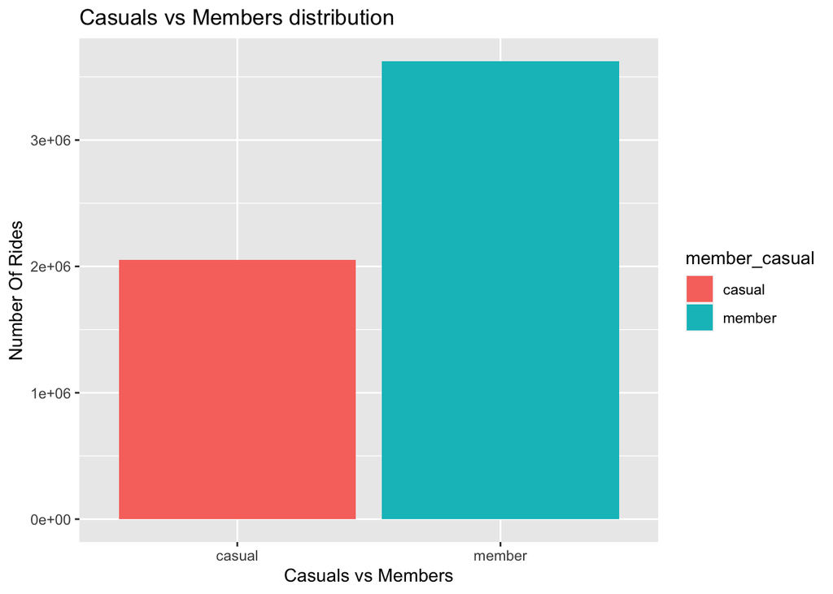

```r
ggplot(cyclistic_data_clean, aes(x = member_casual, fill=member_casual)) +
  geom_bar() +
  labs(x="Casuals vs Members", y="Number Of Rides", title= "Casuals vs Members distribution")
```

##Comparison between Members Causal riders depending on ride length (mean, median, minimum, maximum)

```r
cyclistic_data_clean %>%
  group_by(member_casual) %>%
  summarise(total_ride_length = sum(ride_length),average_ride_length = mean(ride_length), median_length = median(ride_length),
            max_ride_length = max(ride_length), min_ride_length = min(ride_length))
```

```
## # A tibble: 2 × 6
##   member_casual total_ride_length average_ride_length median_length
##   <chr>                     <dbl>               <dbl>         <dbl>
## 1 casual               3488216044               1700.           711
## 2 member               2720052198                750.           511
## # ℹ 2 more variables: max_ride_length <dbl>, min_ride_length <dbl>
```

From the above table we can conclude that casual riders took bike for longer rides than members, average ride length of member riders is lower than the average ride length of casual riders.

##Analyze the ride duration based on days of week and member vs casual

```r
cyclistic_data_clean$day_of_week <- ordered(cyclistic_data_clean$day_of_week, levels=c("Sunday", "Monday", "Tuesday", "Wednesday", "Thursday", "Friday", "Saturday"))
```

```r
cyclistic_data_clean %>%
  group_by(member_casual, day_of_week) %>%
  summarise(number_of_rides = n(),
            average_ride_length = mean(ride_length),.groups="drop") %>%
  arrange(member_casual, day_of_week)
```

```
## # A tibble: 14 × 4
##    member_casual day_of_week number_of_rides average_ride_length
##    <chr>         <ord>                 <int>               <dbl>
##  1 casual        Sunday               333484               1972.
##  2 casual        Monday               234657               1663.
##  3 casual        Tuesday              246760               1503.
##  4 casual        Wednesday            247792               1470.
##  5 casual        Thursday             271080               1488.
##  6 casual        Friday               309480               1656.
##  7 casual        Saturday             408597               1933.
##  8 member        Sunday               402518                838.
##  9 member        Monday               491775                712.
## 10 member        Tuesday              575281                720.
## 11 member        Wednesday            578753                717.
## 12 member        Thursday             588044                718.
## 13 member        Friday               521844                749.
## 14 member        Saturday             466317                837.
```

## Visualize total rides data by type and day of week

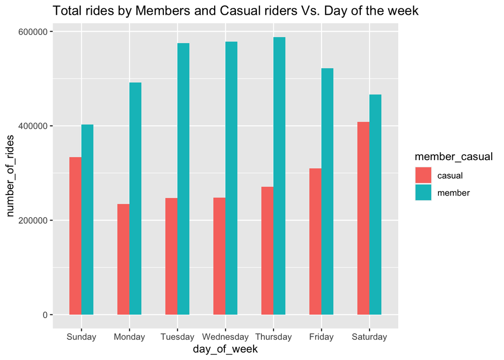

```r
cyclistic_data_clean %>%
  group_by(member_casual, day_of_week) %>%
  summarise(number_of_rides = n(), .groups="drop") %>%
  arrange(member_casual, day_of_week)  %>%
  ggplot(aes(x = day_of_week, y = number_of_rides, fill = member_casual)) +
  labs(title ="Total rides by Members and Casual riders Vs. Day of the week") +
  geom_col(width=0.5, position = position_dodge(width=0.5)) +
  scale_y_continuous(labels = function(x) format(x, scientific = FALSE))
```

Members took consistent trips throughout the week, but there is more rides in Thursday and less rides in Sunday. For casual riders the most taken rides are in weekends, starting rise in Friday followed by Saturday and Sunday.

##Visualize average ride time data by type and day of week

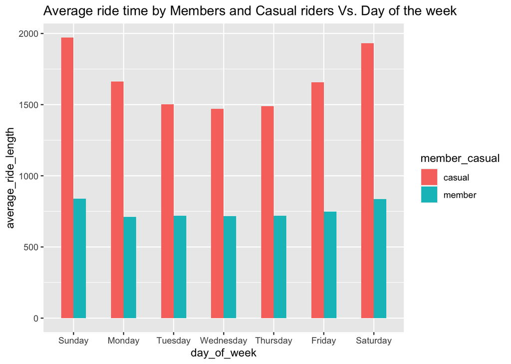

```r
cyclistic_data_clean %>%
  group_by(member_casual, day_of_week) %>%
  summarise(average_ride_length = mean(ride_length), .groups="drop") %>%
  ggplot(aes(x = day_of_week, y = average_ride_length, fill = member_casual)) +
  geom_col(width=0.5, position = position_dodge(width=0.5)) +
  labs(title ="Average ride time by Members and Casual riders Vs. Day of the week")
```

The average ride length for members are much less than that of casual riders. Also it can be seen that weekend average ride length is much higher for casual riders along with total rides.

##Analyze the ride duration by each month for members vs casual riders

```r
cyclistic_data_clean$month <- ordered(cyclistic_data_clean$month, levels=c("January", "February", "March", "April", "May", "June", "July", "August", "September", "October", "November", "December"))
```

```r
cyclistic_data_clean %>%
  group_by(member_casual,month) %>%
  summarise(number_of_rides = n(), average_ride_length = mean(ride_length), .groups = "drop") %>%
  arrange(member_casual, month) %>%
  print(n=24)
```

```
## # A tibble: 24 × 4
##    member_casual month     number_of_rides average_ride_length
##    <chr>         <ord>               <int>               <dbl>
##  1 casual        January             40005               1375.
##  2 casual        February            43014               1392.
##  3 casual        March               62194               1284.
##  4 casual        April              147269               1661.
##  5 casual        May                234153               1711.
##  6 casual        June               301198               1765.
##  7 casual        July               331252               1941.
##  8 casual        August             311006               2115.
##  9 casual        September          261534               1512.
## 10 casual        October            177007               1373.
## 11 casual        November            98327               1197.
## 12 casual        December            44891               1337.
## 13 member        January            150288                622.
## 14 member        February           147422                643.
## 15 member        March              196465                626.
## 16 member        April              279285                702.
## 17 member        May                370603                782.
## 18 member        June               418347                792.
## 19 member        July               436185                822.
## 20 member        August             460430                827.
## 21 member        September          404617                789.
## 22 member        October            359947                729.
## 23 member        November           264042                695.
## 24 member        December           136901                637.
```

##Visualize total rides data by type and month

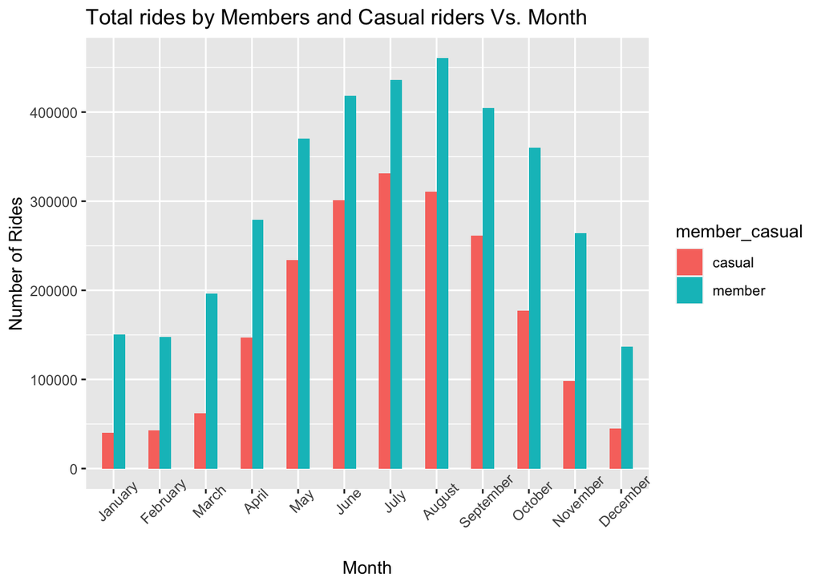

```r
cyclistic_data_clean %>%
  group_by(member_casual, month)%>%
  summarise(number_of_rides = n(), .groups='drop') %>%
  arrange(member_casual, month) %>%
  ggplot(aes(x=month, y=number_of_rides, fill=member_casual))+
  labs(title = "Total rides by Members and Casual riders Vs. Month", x="Month", y="Number of Rides") +
  theme(axis.text.x = element_text(angle = 45))+
  geom_col(width=0.5, position=position_dodge(width=0.5))+
  scale_y_continuous(labels = function(x) format(x, scientific=FALSE))
```

The months June, July, August and September are the most busy time of the year among both members and casual riders. It is possible due to winter there is a significant drop in total rides in the months of November, December, January and February for both type of customers.

##Visualize average ride time data by type and month

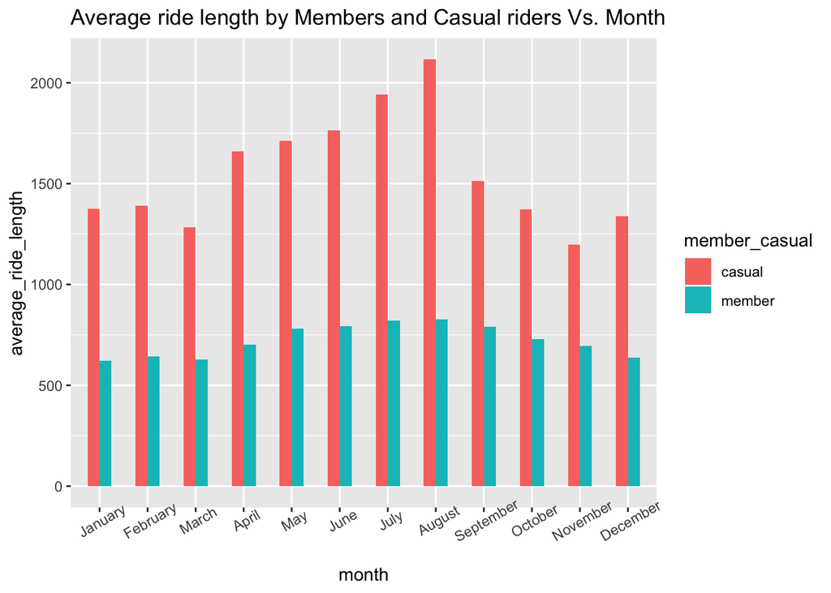

```r
cyclistic_data_clean %>%
  group_by(member_casual, month) %>%
  summarise(average_ride_length = mean(ride_length), .groups ='drop') %>%
  arrange(member_casual, month)%>%
  ggplot(aes(x=month, y=average_ride_length, fill=member_casual)) +
  geom_col(width = 0.5, position = position_dodge(width = 0.5)) +
  labs(title = "Average ride length by Members and Casual riders Vs. Month")+
  theme(axis.text.x= element_text(angle = 30) )
```

##Analyze and visualization on cyclistic’s bike demand by hour in a day

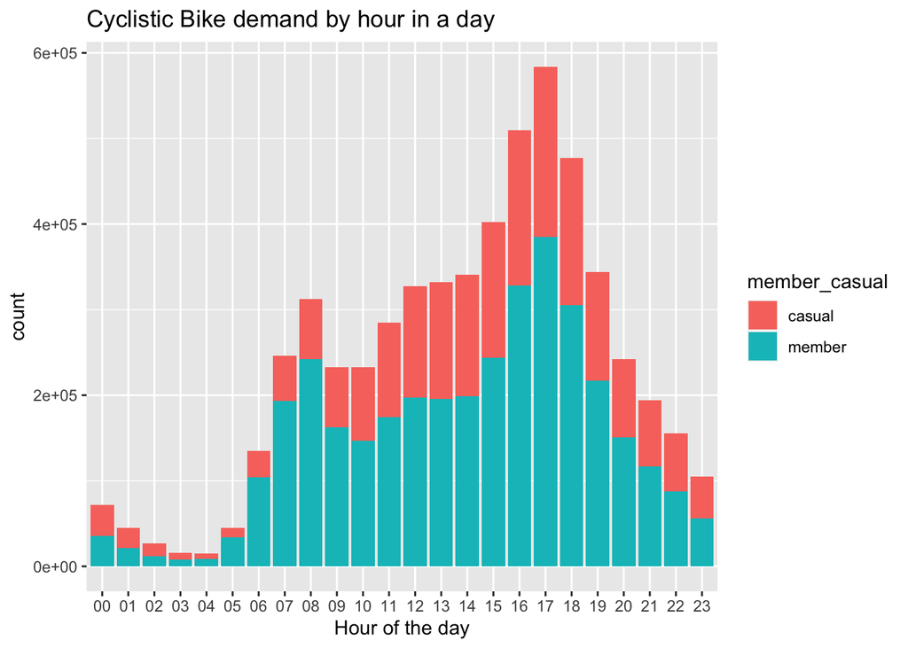

```r
cyclistic_data_clean %>%
  ggplot(aes(start_time, fill=member_casual))+
  labs(x = "Hour of the day", title = "Cyclistic Bike demand by hour in a day")+
  geom_bar()
```

From the chart, we can see for both the member and casual riders perfer between 16pm and 18pm.

##Analyze and visualization of Rideable type Vs. total rides by Members and casual riders

```r
cyclistic_data_clean %>%
  group_by(rideable_type) %>%
  summarise(count = length(ride_id))
```

```
## # A tibble: 3 × 2
##   rideable_type   count
##   <chr>           <int>
## 1 classic_bike  2664597
## 2 docked_bike     80212
## 3 electric_bike 2931573
```

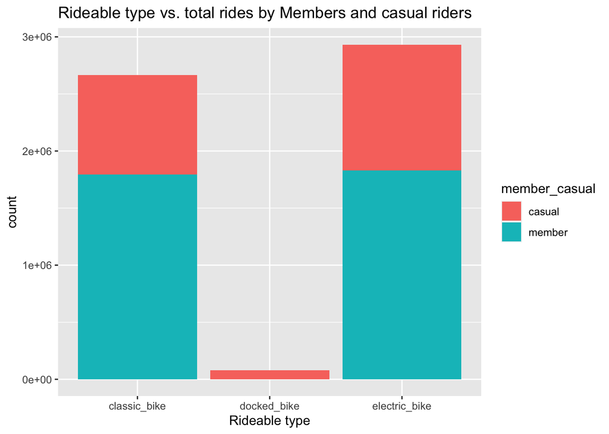

```r
ggplot(cyclistic_data_clean, aes(x=rideable_type, fill = member_casual)) +
  labs(x="Rideable type", title = "Rideable type vs. total rides by Members and casual riders") +
  geom_bar()
```